# THOR Vietnam War Bombing Operations: Exploratory Data Analysis

## 1. Project Overview

This project presents an exploratory data analysis of the **Theater History of Operations Reports (THOR)** Vietnam War bombing operations dataset using R. The dataset documents aerial weapon delivery operations between **1965 and 1975**.

Rather than running complex models, this analysis focuses on **5 core exploratory questions**: 1. When did bombing missions peak during the war? 2. Which countries were targeted most frequently? 3. Which aircraft types carried out the most strikes? 4. How did operational volume divide between day and night? 5. What was the typical weapon payload delivered per mission?

## 2. Loading the Data

```r
# Load the cleaned sample
data <- read.csv("clean_data.csv", stringsAsFactors = FALSE)

# Clean factors for visualization
data$YEAR <- as.factor(data$YEAR)
data$COUNTRY <- ifelse(is.na(data$COUNTRY) | data$COUNTRY == "", "Other/Unknown", data$COUNTRY)
data$PERIOD <- ifelse(is.na(data$PERIOD) | data$PERIOD == "", "Unknown", data$PERIOD)
data$AIRCRAFT_GROUP <- ifelse(is.na(data$AIRCRAFT_GROUP) | data$AIRCRAFT_GROUP == "", "Other", data$AIRCRAFT_GROUP)

# Common clean theme
plot_theme <- theme_minimal(base_size = 12) +
  theme(
    plot.title = element_text(face = "bold", size = 13, color = "#1a252f"),
    plot.subtitle = element_text(size = 10, color = "#555555"),
    axis.title = element_text(face = "bold", size = 11, color = "#2c3e50"),
    panel.grid.minor = element_blank(),
    panel.grid.major.x = element_blank(),
    legend.position = "none"
  )

cat("Total records loaded:", nrow(data), "\nTotal variables:", ncol(data))
```

```
## Total records loaded: 20000
## Total variables: 64
```

## 3. Graph 1: Missions Across Years (1965 - 1975)

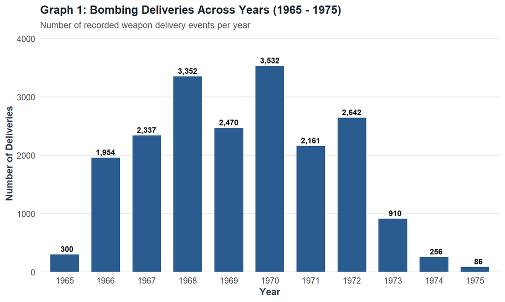

```r
yearly_counts <- as.data.frame(table(Year = data$YEAR))

ggplot(yearly_counts, aes(x = Year, y = Freq)) +
  geom_bar(stat = "identity", fill = "#2b5c8f", width = 0.7) +
  geom_text(aes(label = format(Freq, big.mark = ",")), vjust = -0.5, size = 3.2, fontface = "bold") +
  labs(
    title = "Graph 1: Bombing Deliveries Across Years (1965 - 1975)",
    subtitle = "Number of recorded weapon delivery events per year",
    x = "Year",
    y = "Number of Deliveries"
  ) +
  scale_y_continuous(expand = expansion(mult = c(0, 0.15))) +
  plot_theme
```

## 4. Graph 2: Bombing Operations by Target Country

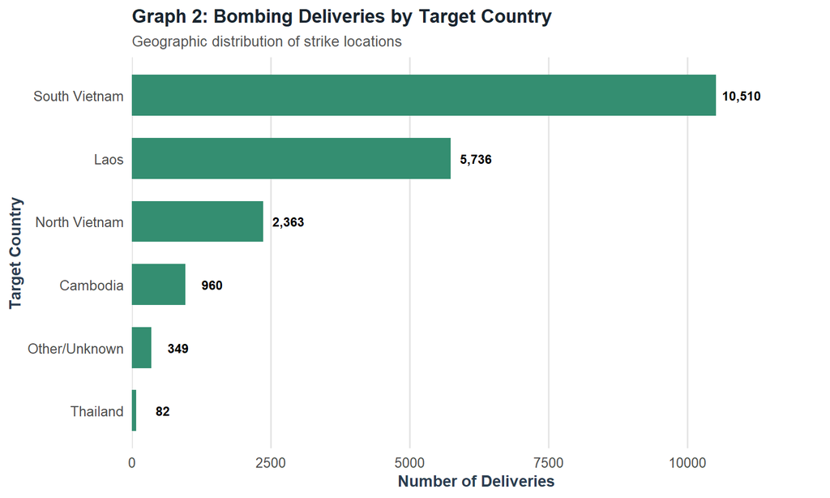

```r
country_counts <- as.data.frame(table(Country = data$COUNTRY))
country_counts <- country_counts[order(country_counts$Freq, decreasing = FALSE), ]
country_counts$Country <- factor(country_counts$Country, levels = country_counts$Country)

ggplot(country_counts, aes(x = Country, y = Freq)) +
  geom_bar(stat = "identity", fill = "#348e71", width = 0.65) +
  geom_text(aes(label = format(Freq, big.mark = ",")), hjust = -0.15, size = 3.2, fontface = "bold") +
  coord_flip() +
  labs(
    title = "Graph 2: Bombing Deliveries by Target Country",
    subtitle = "Geographic distribution of strike locations",
    x = "Target Country",
    y = "Number of Deliveries"
  ) +
  scale_y_continuous(expand = expansion(mult = c(0, 0.18))) +
  plot_theme +
  theme(panel.grid.major.x = element_line(color = "grey90"), panel.grid.major.y = element_blank())
```

**Takeaway**: **South Vietnam** was by far the primary theater (representing over 50% of all sorties), followed by operations in **Laos** focused on disrupting the Ho Chi Minh supply trails.

## 5. Graph 3: Deliveries by Aircraft Group

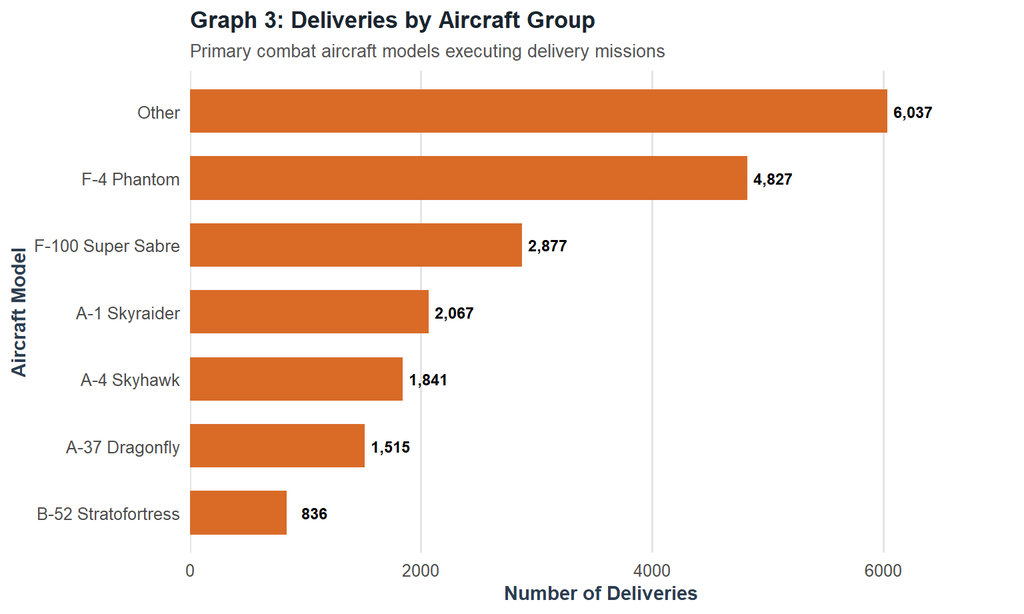

```r
aircraft_counts <- as.data.frame(table(Aircraft = data$AIRCRAFT_GROUP))
aircraft_counts <- aircraft_counts[order(aircraft_counts$Freq, decreasing = FALSE), ]
aircraft_counts$Aircraft <- factor(aircraft_counts$Aircraft, levels = aircraft_counts$Aircraft)

ggplot(aircraft_counts, aes(x = Aircraft, y = Freq)) +
  geom_bar(stat = "identity", fill = "#d96b27", width = 0.65) +
  geom_text(aes(label = format(Freq, big.mark = ",")), hjust = -0.15, size = 3.2, fontface = "bold") +
  coord_flip() +
  labs(
    title = "Graph 3: Deliveries by Aircraft Group",
    subtitle = "Primary combat aircraft models executing delivery missions",
    x = "Aircraft Model",
    y = "Number of Deliveries"
  ) +
  scale_y_continuous(expand = expansion(mult = c(0, 0.18))) +
  plot_theme +
  theme(panel.grid.major.x = element_line(color = "grey90"), panel.grid.major.y = element_blank())
```

**Takeaway**: Among specific aircraft models, the twin-engine **F-4 Phantom** recorded the highest operational frequency, serving as the versatile backbone of tactical air operations.

## 6. Graph 4: Day vs. Night Operational Split

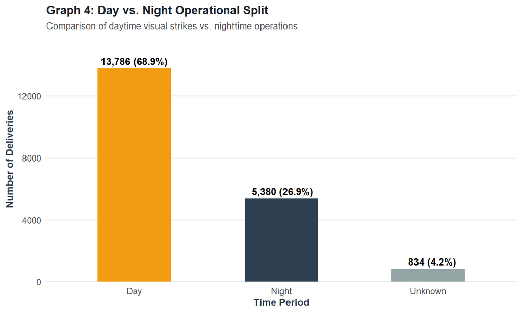

```r
period_counts <- as.data.frame(table(Period = data$PERIOD))
period_counts$Percentage <- round(100 * period_counts$Freq / sum(period_counts$Freq), 1)

ggplot(period_counts, aes(x = Period, y = Freq, fill = Period)) +
  geom_bar(stat = "identity", width = 0.5) +
  scale_fill_manual(values = c("Day" = "#f39c12", "Night" = "#2c3e50", "Unknown" = "#95a5a6")) +
  geom_text(aes(label = paste0(format(Freq, big.mark = ","), " (", Percentage, "%)")),
            vjust = -0.5, size = 3.8, fontface = "bold") +
  labs(
    title = "Graph 4: Day vs. Night Operational Split",
    subtitle = "Comparison of daytime visual strikes vs. nighttime operations",
    x = "Time Period",
    y = "Number of Deliveries"
  ) +
  scale_y_continuous(expand = expansion(mult = c(0, 0.15))) +
  plot_theme
```

**Takeaway**: **~68.9%** of all recorded missions took place in Daylight. Visual acquisition was essential in jungle and rural terrain prior to widespread night-vision and precision-guided systems.

## 7. Graph 5: Distribution of Weapon Load (lb)

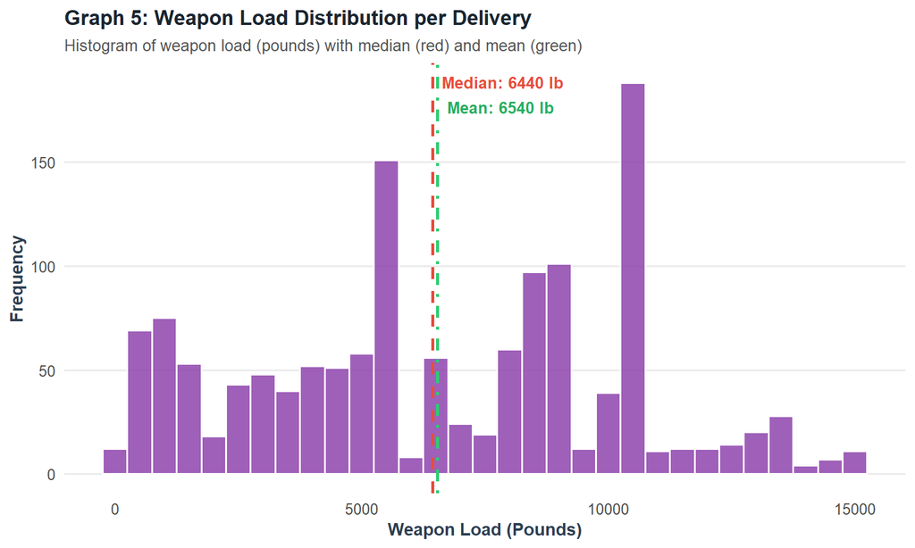

```r
load_data <- data[!is.na(data$LOAD_LB) & data$LOAD_LB > 0 & data$LOAD_LB <= 15000, ]
med_load <- median(load_data$LOAD_LB)
mean_load <- mean(load_data$LOAD_LB)

ggplot(load_data, aes(x = LOAD_LB)) +
  geom_histogram(binwidth = 500, fill = "#8e44ad", color = "white", alpha = 0.85) +
  geom_vline(aes(xintercept = med_load), color = "#e74c3c", linetype = "dashed", linewidth = 1) +
  geom_vline(aes(xintercept = mean_load), color = "#2ecc71", linetype = "dotdash", linewidth = 1) +
  annotate("text", x = med_load + 200, y = Inf, vjust = 2, hjust = 0,
           label = paste0("Median: ", round(med_load), " lb"), color = "#e74c3c", fontface = "bold", size = 3.6) +
  annotate("text", x = mean_load + 200, y = Inf, vjust = 4, hjust = 0,
           label = paste0("Mean: ", round(mean_load), " lb"), color = "#27ae60", fontface = "bold", size = 3.6) +
  labs(
    title = "Graph 5: Weapon Load Distribution per Delivery",
    subtitle = "Histogram of weapon load (pounds) with median (red) and mean (green)",
    x = "Weapon Load (Pounds)",
    y = "Frequency"
  ) +
  plot_theme
```